# T cell transfer single cell analysis - Stroma fraction

23 February, 2024

```r
library(Seurat)
library(ggplot2)
library(cowplot)
library(clustree)
library(dplyr)
library(reshape2)

source("../code/SingleCell/color_list.R")
```

```r
datadir = "../data/SingleCell/TcellTransfer/R_objects/"

owncache = "../data/SingleCell/TcellTransfer/cache_stroma/"

violintheme = theme(axis.text = element_text(size = 8),
        plot.title = element_text(size = 8),
        legend.key.size = unit(8, "pt"),
        axis.title = element_blank())
dimtheme = theme(legend.text = element_text(size = 8),
        plot.title = element_text(size = 8),
        legend.key.size = unit(8, "pt"))

qc_feats <- c("nFeature_RNA", "nCount_RNA", "percent_mito", "percent_ribo")
```

# 1 Initial data

```r
if(!file.exists(paste0(owncache,"first_dr.RData"))){
  alldata = readRDS(paste0(datadir,"stroma_data.rds"))

  DefaultAssay(alldata) = "RNA"

suppressWarnings(
  suppressMessages(
    alldata <-FindVariableFeatures(alldata, selection.method = "vst",
                                   nfeatures = 2000, verbose = FALSE,
                                   assay = "RNA")))

  alldata <- ScaleData(alldata, vars.to.regress = c("percent_mito", "nFeature_RNA"),
      assay = "RNA")
  alldata <- RunPCA(alldata, npcs = 50, verbose = F)
  alldata <- RunUMAP(alldata, reduction = "pca", dims = 1:30,
                     n.components = 2, n.neighbors = 30,
      n.epochs = 200, min.dist = 0.3, learning.rate = 1,
      spread = 1, reduction.name = "umap")

  if(file.exists(owncache)){
    save(alldata, file = paste0(owncache,"first_dr.RData"))
  }
}else{
  load(paste0(owncache,"first_dr.RData"))
}
```

# 2 Quality control

Number of features and counts and percentage of mitochondrial and ribosomal RNA are plotted below.

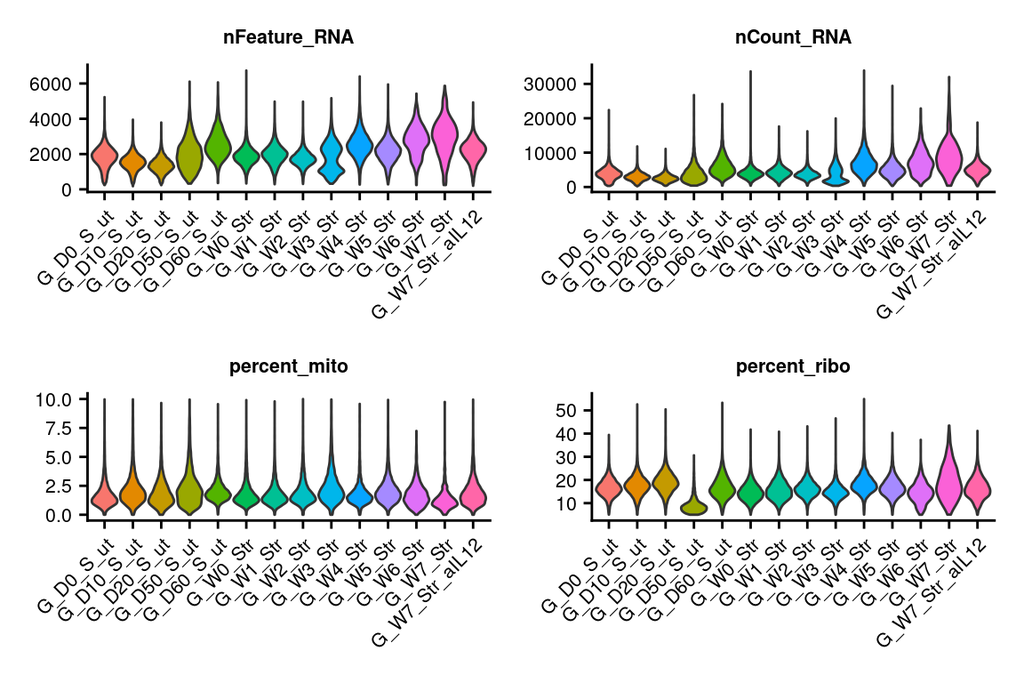

```r
VlnPlot(alldata, group.by = "orig.ident", features = qc_feats, pt.size = 0, ncol = 2) &
  violintheme
```

# 3 Dimensional reduction - pre-integration

The data is first processed in the same way as the full dataset, with PCA on the 2000 most highly variable genes and subsequent UMAP for visualization. As can be seen below, some differences can be seen between the Rag2-/- and SCID backgrounds at this level of reduction.

## 3.1 Highly variable features

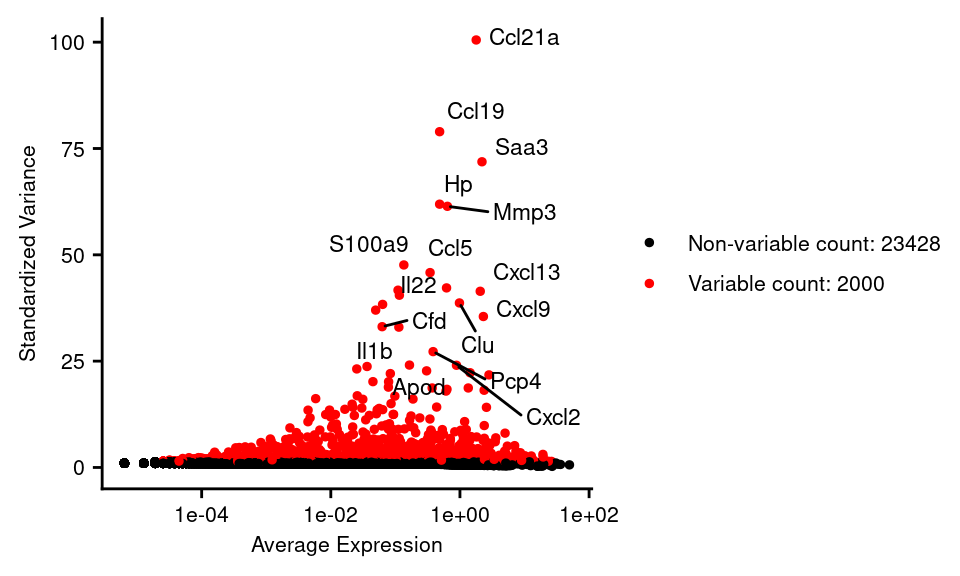

```r
top20 <- head(VariableFeatures(alldata), 20)
lp = LabelPoints(plot = VariableFeaturePlot(alldata), points = top20, repel = TRUE) +
  theme(axis.title = element_text(size = 8),
        legend.text = element_text(size = 8),
        axis.text = element_text(size = 8))

lp$layers[[2]]$aes_params$size = 3

lp
```

## 3.2 PCA

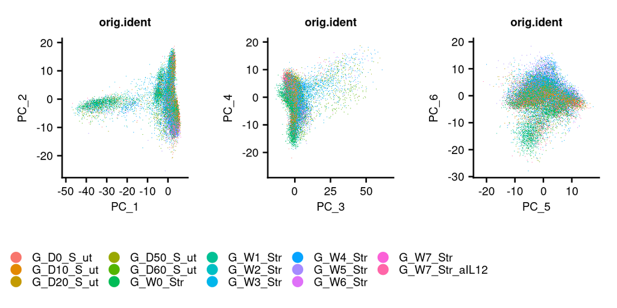

```r
plot_grid(plot_grid(ncol = 3,
          DimPlot(alldata, reduction = "pca", group.by = "orig.ident",
                  dims = 1:2, shuffle = TRUE) +
            NoLegend() + dimtheme +
            theme(axis.text = element_text(size = 8),
                  axis.title = element_text(size = 8)),
          DimPlot(alldata, reduction = "pca", group.by = "orig.ident",
                  dims = 3:4, shuffle = TRUE) +
            NoLegend() + dimtheme +
            theme(axis.text = element_text(size = 8),
                  axis.title = element_text(size = 8)),
          DimPlot(alldata, reduction = "pca", group.by = "orig.ident",
                  dims = 5:6, shuffle = TRUE) +
            NoLegend() + dimtheme +
            theme(axis.text = element_text(size = 8),
                  axis.title = element_text(size = 8))),
         get_legend(
           DimPlot(alldata, reduction = "pca", group.by = "orig.ident") +
             theme(legend.position = "top") + dimtheme),
         ncol = 1, rel_heights = c(3,1))
```

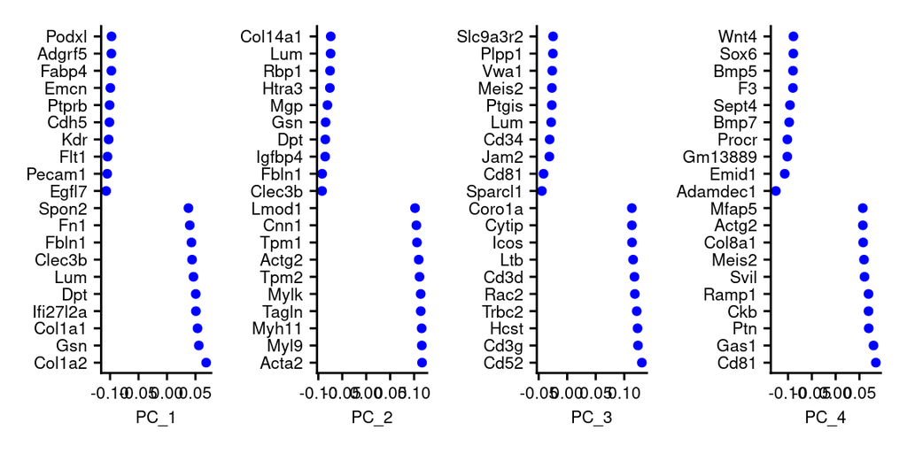

```r
VizDimLoadings(alldata, dims = 1:4, reduction = "pca",
               ncol = 4, balanced = T, nfeatures = 20) &
  theme(axis.text = element_text(size = 8),
        axis.title = element_text(size = 8))
```

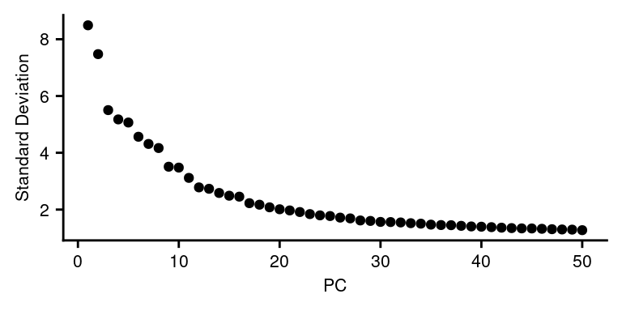

```r
ElbowPlot(alldata, reduction = "pca", ndims = 50) +
  theme(axis.text = element_text(size = 8),
        axis.title = element_text(size = 8))
```

## 3.3 UMAP

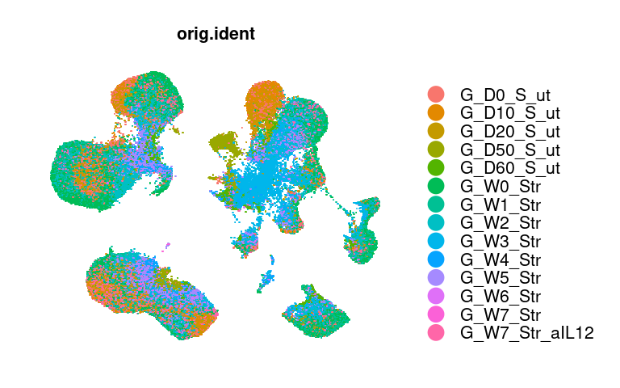

```r
plot_grid(ncol = 1, DimPlot(alldata, reduction = "umap", raster = TRUE,
                            group.by = "orig.ident", shuffle = TRUE) +
            theme(legend.position = "right") + NoAxes() + dimtheme)
```

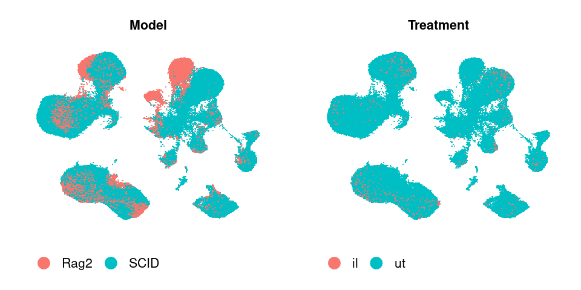

```r
plot_grid(ncol = 2,
      DimPlot(alldata, reduction = "umap", raster = TRUE,
                  group.by = "Model", shuffle = TRUE) +
            theme(legend.position = "bottom") + NoAxes() + dimtheme,
      DimPlot(alldata, reduction = "umap", raster = TRUE,
                  group.by = "Treatment", shuffle = TRUE) +
            theme(legend.position = "bottom") + NoAxes() + dimtheme)
```

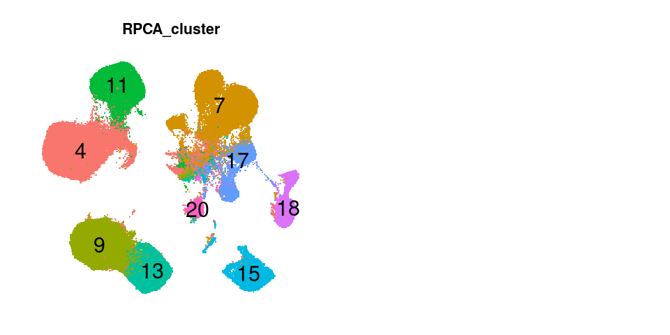

```r
plot_grid(ncol = 2,
          DimPlot(alldata, reduction = "umap", raster = TRUE,
                  group.by = "RPCA_cluster", label = TRUE, shuffle = TRUE) +
            NoLegend() + NoAxes() + dimtheme)
```

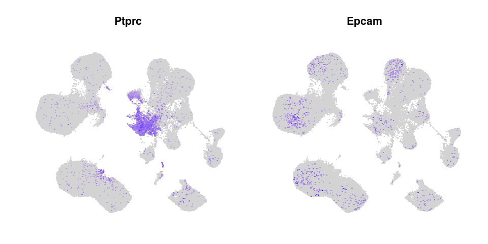

```r
FeaturePlot(alldata, reduction = "umap", features = c("Ptprc","Epcam"), raster = TRUE,
    order = T, slot = "data", combine = T) & dimtheme & NoAxes() & NoLegend()
```

# 4 Integration

To enable equivalent clustering across samples, CCA integration is run with standard Seurat functions.

```r
plan("multisession", workers = 6)

if(!file.exists(paste0(owncache,"integration.RData"))){
  if(!file.exists(paste0(owncache,"anchors.RData"))){

    # Works with 256GB on 6 workers
    alldata <- SplitObject(alldata, split.by = "orig.ident")

    alldata = lapply(alldata, function(x){
        x <- NormalizeData(x, verbose = FALSE)
        x <- FindVariableFeatures(x, selection.method = "vst",
                nfeatures = 2000, verbose = FALSE)
      })

    data.anchors <- FindIntegrationAnchors(object.list = alldata,
                                                dims = 1:30, reduction = "cca")
    rm(alldata)
    gc()

    if(file.exists(owncache)){
          save(data.anchors, file = paste0(owncache,"anchors.RData"))
    }
  }else{
    rm(alldata)
    gc()
    load(paste0(owncache,"anchors.RData"))
  }

  plan("sequential")

  # works with 256GB in sequential
  alldata <- IntegrateData(anchorset = data.anchors, dims = 1:30, new.assay.name = "CCA",
     sample.tree = cbind(c(-4,-1,2,3,-8,5,-10,7,-15,9,4,8,11,12),
                         c(-5,-2,-3,1,-7,-6,-11,-12,-14,-13,6,10,-9,13)))

  rm(data.anchors)
  gc()

  alldata <- ScaleData(alldata)
  alldata <- RunPCA(alldata, npcs = 30, verbose = FALSE)
  alldata <- RunUMAP(alldata, dims = 1:30)

  if(file.exists(owncache)){
    save(alldata, file = paste0(owncache,"integration.RData"))
  }
}else{
  load(paste0(owncache,"integration.RData"))
}

plan("sequential")
```

## 4.1 Dimensional reduction

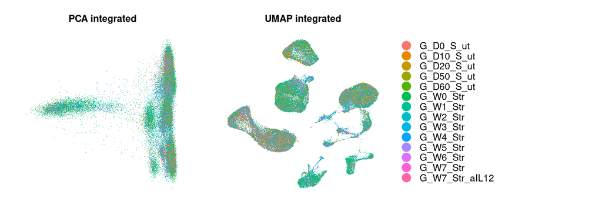

```r
plot_grid(ncol = 3,
          DimPlot(alldata, reduction = "pca", group.by = "orig.ident",
                  pt.size = 0.01, shuffle = TRUE) +
            NoAxes() + ggtitle("PCA integrated") + NoLegend() + dimtheme,
          DimPlot(alldata, reduction = "umap", group.by = "orig.ident",
                  pt.size = 0.01, shuffle = TRUE) +
            NoAxes() + ggtitle("UMAP integrated") + NoLegend() + dimtheme,
          get_legend(DimPlot(alldata, reduction = "pca", group.by = "orig.ident") +
                       theme(legend.text = element_text(size = 8)) + dimtheme)
)
```

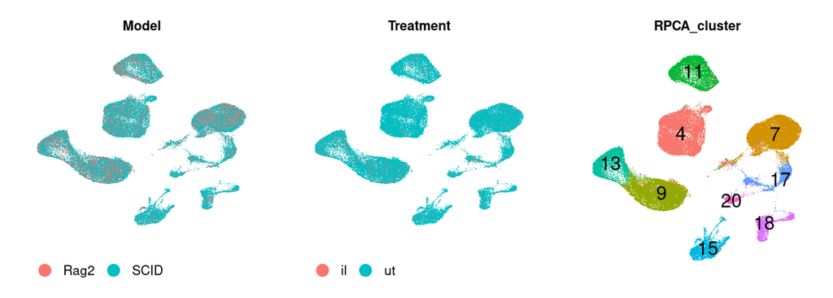

```r
plot_grid(ncol = 3,
          DimPlot(alldata, reduction = "umap", group.by = "Model",
                  pt.size = 0.01, shuffle = TRUE) +
            NoAxes() + dimtheme + theme(legend.position = "bottom"),
          DimPlot(alldata, reduction = "umap", group.by = "Treatment",
                  pt.size = 0.01, shuffle = TRUE) +
            NoAxes() + dimtheme + theme(legend.position = "bottom"),
          DimPlot(alldata, reduction = "umap", group.by = "RPCA_cluster",
                  pt.size = 0.01, shuffle = TRUE, label = TRUE) +
            NoAxes() + NoLegend() + dimtheme
)
```

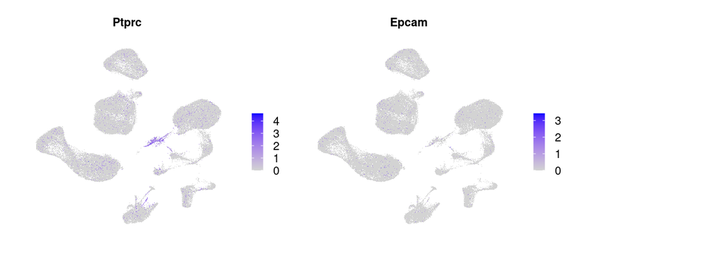

```r
alldata@active.assay = "RNA"
plot_grid(FeaturePlot(alldata, reduction = "umap", features = c("Ptprc","Epcam"),
    order = T, slot = "data", combine = T) & dimtheme & NoAxes(),
    NULL, rel_widths = c(4,1))
```

```r
alldata@active.assay = "CCA"
```

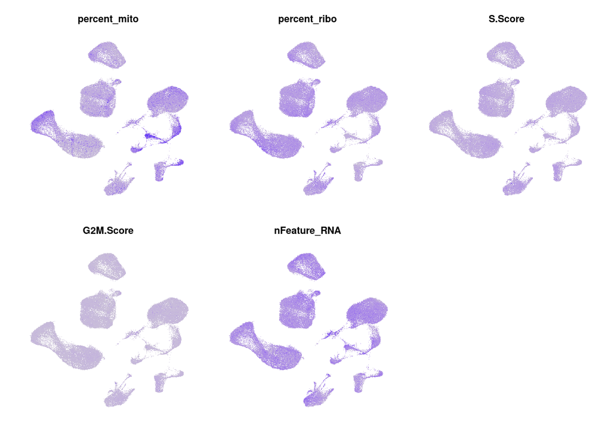

```r
FeaturePlot(alldata, reduction = "umap",
            features = c("percent_mito","percent_ribo","S.Score",
                         "G2M.Score", "nFeature_RNA"),
    order = T, slot = "data", combine = T, ncol = 3) &
  NoAxes() & NoLegend() & dimtheme
```

# 5 Clustering

The dataset is clustered using SNN and the Louvain algorithm at 4 resolutions. Resolution 0.5 is chosen for further analysis.

```r
if(!file.exists(paste0(owncache, "clustered.RData"))){
  alldata@active.assay <- "CCA"

  alldata@active.assay

  alldata <- FindNeighbors(alldata, dims = 1:30, k.param = 350, prune.SNN = 1/15)


  # Clustering with louvain (algorithm 1)
  for (res in c(0.25, 0.5, 1, 1.5)) {
      alldata <- FindClusters(alldata, graph.name = "CCA_snn",
                              resolution = res, algorithm = 1)
  }
  if(file.exists(owncache)){
    save(alldata, file = paste0(owncache, "clustered.RData"))
  }
}else{
  load(paste0(owncache, "clustered.RData"))
}
```

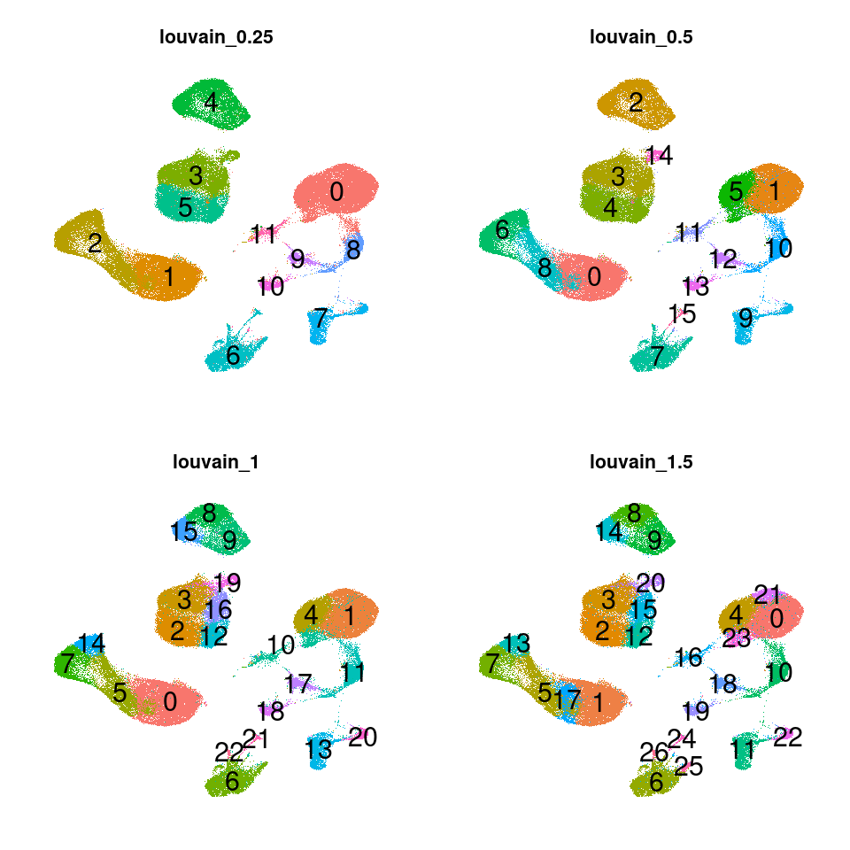

```r
plot_grid(ncol = 2,
          DimPlot(alldata, reduction = "umap", group.by = "CCA_snn_res.0.25",
                  label = TRUE) + dimtheme + NoLegend() + NoAxes() +
            ggtitle("louvain_0.25"),
          DimPlot(alldata, reduction = "umap", group.by = "CCA_snn_res.0.5",
                  label = TRUE) + dimtheme +  NoLegend() + NoAxes() +
            ggtitle("louvain_0.5"),
          DimPlot(alldata, reduction = "umap", group.by = "CCA_snn_res.1",
                  label = TRUE) + dimtheme + NoLegend() + NoAxes() +
            ggtitle("louvain_1"),
          DimPlot(alldata, reduction = "umap", group.by = "CCA_snn_res.1.5",
                  label = TRUE) + dimtheme + NoLegend() + NoAxes() +
            ggtitle("louvain_1.5"))
```

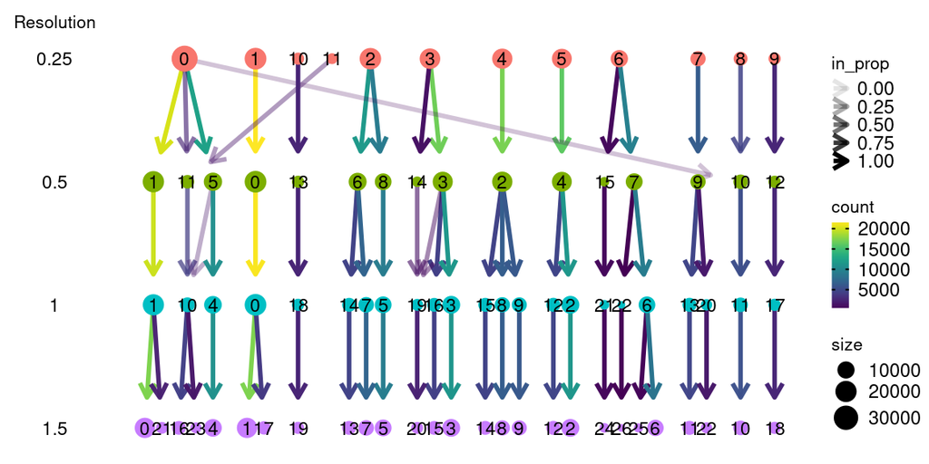

```r
ct = clustree(alldata@meta.data, prefix = "CCA_snn_res.")

ct$layers[[1]]$aes_params$edge_width = 1

plot_grid(ggplot(unique(ct$data[,c("y","CCA_snn_res.")]),
       aes(y = y)) +
  geom_text(x = 1, aes(label = CCA_snn_res.), size = 3) +
  scale_x_continuous(limits = c(0,2), position = "top") +
  theme(panel.background = element_blank(),
        panel.grid = element_blank(),
        axis.text = element_blank(),
        axis.title.y = element_blank(),
        axis.title.x = element_text(size = 8),
        axis.ticks = element_blank()) +
    labs(x= "Resolution"),
  ct +
  scale_size_continuous(range = c(1,5)) +
  scale_colour_discrete(guide = "none") +
  theme(legend.key.size = unit(8,"pt"),
        legend.title = element_text(size = 8),
        legend.margin = margin(1,1,1,1,unit = "pt")),
  align = "h", rel_widths = c(1,8))
```

# 6 Differential expression and annotation of clusters

The different clusters are annotated using differential expression and known marker genes. For legibility, the annotations are here given prior to differential expression and gene marker information.

```r
clusternames =
  data.frame(Cluster = c(0:15),
             Clustername = c("FiB Has1","MyoC Hhip","Telocytes",
                             "FiB Adamdec1","FiB Wnt4","MyoC Actc1",
                             "Trophocytes","Endothelial","FiB Igfbp6",
                             "Pericytes","MyoC Id4","Immune","Neurons",
                             "ICC","ImmunoFiB","LEC"))

clusterorder =
  c("FiB Has1","FiB Adamdec1","FiB Wnt4","FiB Igfbp6","ImmunoFiB",
    "Trophocytes","Telocytes","MyoC Hhip","MyoC Actc1","MyoC Id4",
    "Endothelial","Pericytes","LEC","Neurons","ICC","Immune")

alldata = AddMetaData(alldata,
                      factor(clusternames$Clustername[
                        match(alldata$CCA_snn_res.0.5,clusternames$Cluster)],
                        levels = clusterorder),
                      "NamedCluster")

alldata = SetIdent(alldata, value = "NamedCluster")

color_list = get_color_list(16)
names(color_list) = clusterorder
```

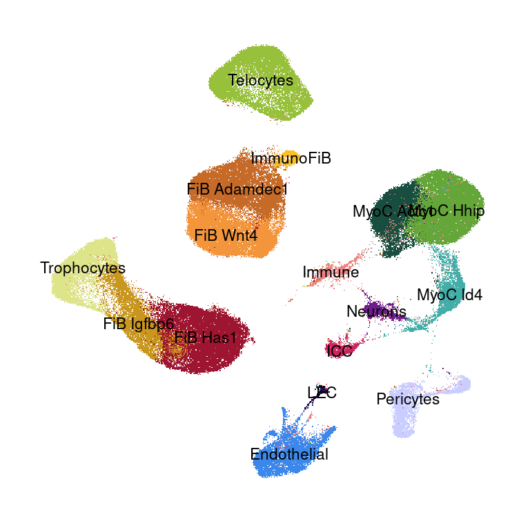

```r
dp = DimPlot(alldata, label = TRUE, shuffle = TRUE) +
  NoAxes() + NoLegend() + dimtheme + scale_color_manual(values = color_list)

dp$layers[[2]]$aes_params$size = 3

dp
```

## 6.1 Differential expression

The top 25 DEGs (based on p-value) for each cluster are shown below, ordered by log2(FC).

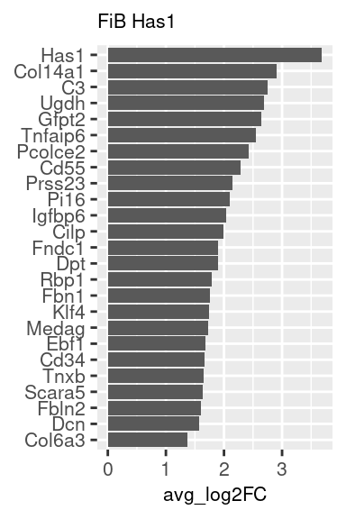

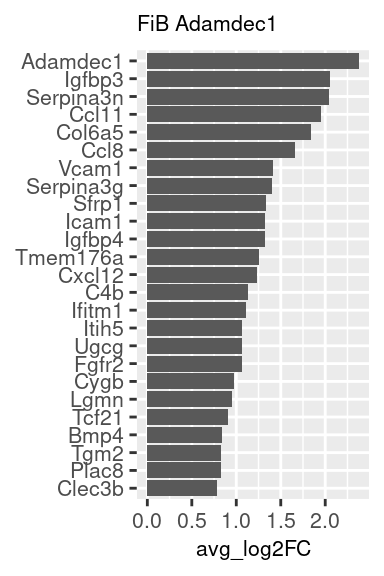

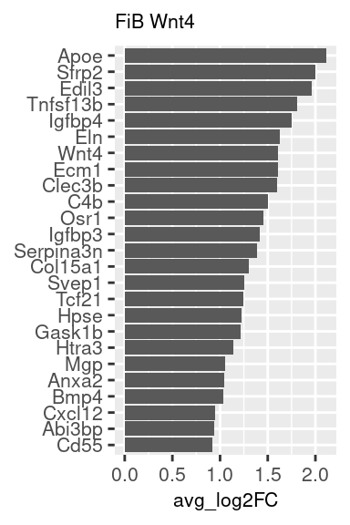

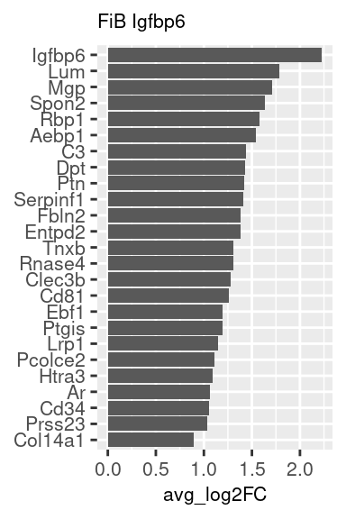

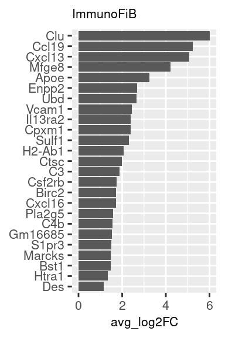

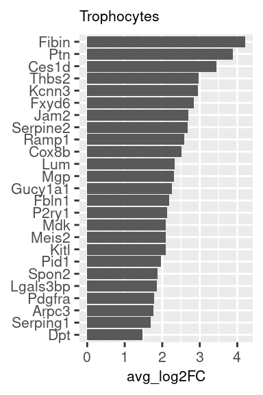

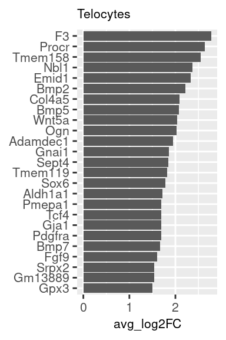

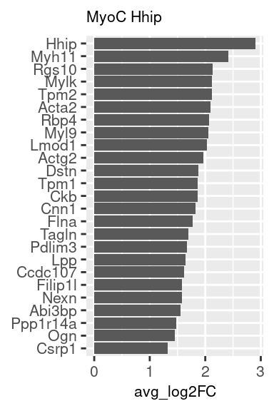

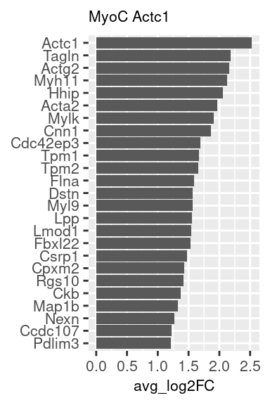

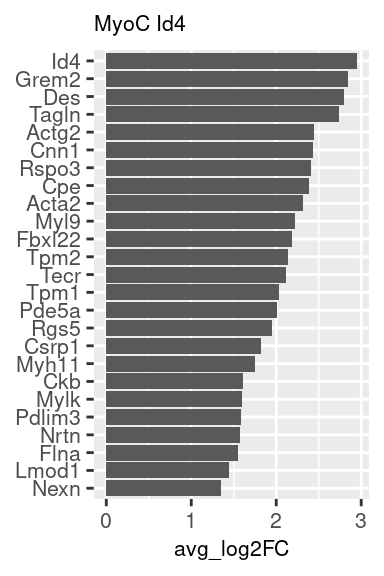

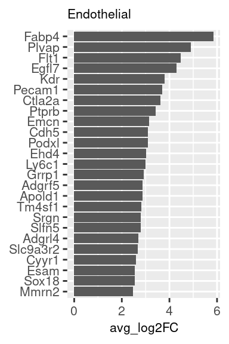

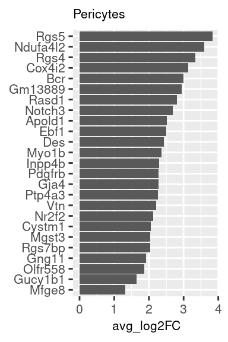

[4 more figures not shown]

```r
alldata@active.assay = "RNA"

# Becomes slower when parallel

plan("sequential")

if(!file.exists(paste0(owncache, "clustermarkers.rds"))){
  markers_genes <- FindAllMarkers(alldata, logfc.threshold = 0.2, test.use = "wilcox",
    min.pct = 0.1, min.diff.pct = 0.2, only.pos = TRUE, max.cells.per.ident = 1000,
    assay = "RNA", random.seed = 42)

  if(file.exists(owncache)){
    saveRDS(markers_genes, paste0(owncache, "clustermarkers.rds"))
  }
}else{
   markers_genes = readRDS(paste0(owncache, "clustermarkers.rds"))
}

top25 <- markers_genes %>% group_by(cluster) %>% top_n(-25, p_val)

out = lapply(unique(top25$cluster), function(i){
  markersdata = top25[top25$cluster==i,]
  markersdata$gene =
    factor(markersdata$gene,
           levels = markersdata$gene[order(markersdata$avg_log2FC)])
  print(ggplot(markersdata, aes(x = avg_log2FC, y = gene)) +
          labs(title = i) +
    geom_bar(stat = "identity") +
    theme(axis.title.y = element_blank(),
          axis.title.x = element_text(size = 8),
          plot.title = element_text(size = 8),
          axis.text = element_text(size = 8)))
})
```

```r
markergenes =
  c("Cd34","Col1a1","Grem1","Has1","Pdpn","Igfbp3","Adamdec1",
    "Col6a5","Wnt4","Igfbp6","Gas1","Clu","Ccl19","Cxcl13",
    "Pdgfra","Ptn","Fibin","Wnt5a","Bmp5","Foxl1","Myh11","Acta2",
    "Myl9","Hhip","Actc1","Id4","Plvap","Cdh5","Cd81","Cxcl12",
    "Rgs5","Pdgfrb","Pln","Ccl21a","Lyve1","Prox1","Nog","Pcp4",
    "Nrtn","Kit","Etv1","Ano1","Ptprc")
```

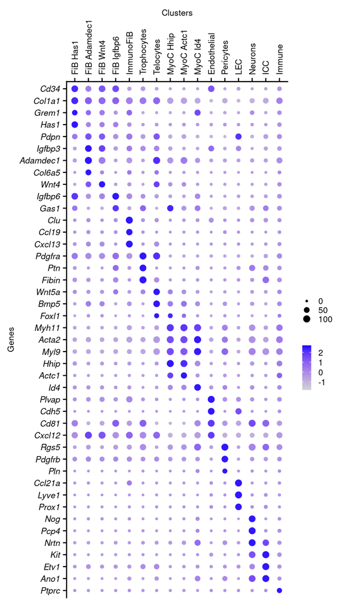

```r
alldata@active.ident = factor(alldata$NamedCluster,
                              levels = clusterorder)
dot = DotPlot(alldata, features=rev(markergenes))
dot = dot + aes(x = id, y = features.plot) +
  scale_x_discrete(position = "top") +
  labs(y = "Genes",x = "Clusters") +
  scale_size(range = c(0.5,2.5), breaks = c(0,50,100), limits = c(0,100)) +
  theme(legend.position = "right", legend.title = element_blank(),
        axis.text.x.top = element_text(size = 8, angle = 90, vjust =0.5,
                                   hjust = 0),
        axis.text.y = element_text(size = 8, face = "italic"),
        legend.key.width = unit(0.3, "cm"),
        legend.key.height = unit(0.3,"cm"),
        legend.text = element_text(size = 8),
        axis.title = element_text(size = 8))
dot$scales$scales[[1]]$limits = c(-1.8,2.7)

print(dot)
```

# 7 Population changes over time

The proportion of each cluster among the total stromal population is shown across time points below. The order of clusters is based on the average correlation between proportion and time point for each background (untreated samples only), with positive correlation at the top and negative correlation on the bottom.

Note that the "Immune" cluster has been excluded from this analysis.

```r
clean_sample_names = function(sam){
  for(s in c("_Imm","I_","_Epi","_E","_Str","S_","_ut","G_")){
    sam = gsub(s, "",sam)
  }
  gsub("il","aIL12",gsub("_","\n",sam))
}
```

```r
alldata$Treatment = factor(alldata$Treatment,
                           levels = c("ut","il"))

frequencies = as.data.frame(table(data.frame(cluster=alldata$NamedCluster,
                 sample = alldata$orig.ident, model = alldata$Model)))
frequencies = frequencies[frequencies$cluster != "Immune",]
frequencies$Proportion=NA
for(i in 1:nrow(frequencies)){
  frequencies$Proportion[i] =
    frequencies$Freq[i]/
    sum(frequencies$Freq[frequencies$sample==frequencies$sample[i]])
}

frequencies$time = alldata$Time[match(frequencies$sample,
                                      alldata$orig.ident)]
frequencies$treatment =
  alldata$Treatment[match(frequencies$sample,
                          alldata$orig.ident)]

frequencies = frequencies[
  (substr(frequencies$time,1,1) == "W" & frequencies$model == "SCID") |
    (substr(frequencies$time,1,1) == "D" & frequencies$model == "Rag2"),]


clustercors = lapply(c("SCID","Rag2"), function(bg){
  corlist = lapply(unique(frequencies$cluster), function(i){
    clufreq = frequencies[frequencies$cluster==i  &
                          frequencies$treatment == "ut" &
                          frequencies$model == bg,]

    clucor = cor(clufreq$Proportion,as.numeric(
      as.factor(as.character(clufreq$time))))
    clucor
    })
  names(corlist) = unique(frequencies$cluster)
  corlist
  })
names(clustercors) = c("SCID","Rag2")

averagecor = lapply(1:length(clustercors[[1]]), function(i){
  mean(c(clustercors[[1]][[i]], clustercors[[2]][[i]]))
})
names(averagecor) = names(clustercors[[1]])

frequencies$cluster =
  factor(frequencies$cluster,
         levels = names(averagecor)[order(unlist(averagecor),
                                          decreasing = TRUE)])

frequencies$sample =
  factor(frequencies$sample,
         levels =
           unique(frequencies$sample[
             order(factor(frequencies$model, levels = c("SCID","Rag2")),
                   frequencies$treatment,
                   frequencies$time)]))
frequencies$samplenumber = as.numeric(frequencies$sample)


cumulFreq = frequencies
cumulFreq$cumulProp = NA
for(i in unique(cumulFreq$sample)){
  cumulFreq$cumulProp[cumulFreq$sample %in% i] = rev(cumsum(rev(cumulFreq$Proportion[cumulFreq$sample %in% i])))
}
cumulFreq = rbind(cumulFreq,cumulFreq)
cumulFreq$xadj = rep(c(-1,1), c(nrow(frequencies),nrow(frequencies)))
cumulFreq$oldtime = cumulFreq$time
cumulFreq$time = as.numeric(
  gsub("D","",gsub("W","",as.character(cumulFreq$time))))

datasets = lapply(names(clustercors), function(bg){
  bgfreq = frequencies[frequencies$model == bg,]
  bglist = lapply(unique(bgfreq$treatment), function(i){
    trfr = bgfreq[bgfreq$treatment==i,]
    cumtrfr = cumulFreq[paste(cumulFreq$sample,
                                     cumulFreq$model,
                                     cumulFreq$oldtime) %in%
                                 paste(trfr$sample,
                                       trfr$model,
                                       trfr$time),]
    list(trfr, cumtrfr)
  })
  names(bglist) = unique(bgfreq$treatment)
  bglist
})

barplot = ggplot(data = frequencies,
       aes(x = samplenumber, y = Proportion, fill = cluster)) +
  theme(panel.background = element_blank(), axis.title.x = element_blank(),
        axis.text.x = element_text(angle = 90, hjust = 1, vjust = 0.5)) +
            scale_fill_manual(
              values =
                color_list[as.character(unique(sort(frequencies$cluster)))]) +
            scale_x_continuous(
              breaks = sort(unique(frequencies$samplenumber)),
              labels = clean_sample_names(levels(frequencies$sample)))

for(ds in datasets){
  for(dst in ds){
    barplot = barplot +
      geom_area(data = dst[[2]],
                alpha = 0.7, size = 0.3, stat = 'identity',
                aes(fill = cluster, group = cluster,
                    y = Proportion, x = samplenumber + xadj*0.3))}
}
```

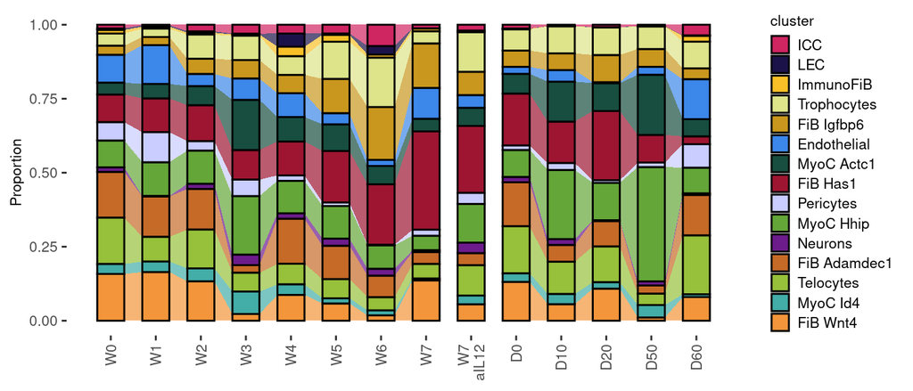

```r
barplot + geom_bar(stat = "identity", width = 0.6, color = "black") +
  theme(axis.text = element_text(size = 8),
        axis.title = element_text(size = 8),
        legend.text = element_text(size = 8),
        legend.title = element_text(size = 8),
        legend.key.size = unit(11,"pt"))
```

# 8 Subset analyses

```r
DefaultAssay(alldata) = "RNA"

alldata$ModelTreatmentTime = paste(alldata$Model,
                                     alldata$Treatment,
                                     alldata$Time)
alldata$ModelTreatmentTime = factor(alldata$ModelTreatmentTime,
      levels = unique(alldata$ModelTreatmentTime[order(
        factor(alldata$Model, levels = c("SCID", "Rag2")),
        factor(alldata$Treatment, levels = c("ut","il")),
        alldata$Time)]))
alldata$ModelTreatment = paste(alldata$Model,
                                     alldata$Treatment)
alldata$ModelTreatment = factor(alldata$ModelTreatment,
      levels = unique(alldata$ModelTreatment[order(
        factor(alldata$Model, levels = c("SCID", "Rag2")),
        factor(alldata$Treatment, levels = c("ut","il")))]))

alldata = AddMetaData(alldata, alldata$NamedCluster, "fibroblasts")

alldata$fibroblasts[!(alldata$fibroblasts %in%
                  c("FiB Has1","FiB Adamdec1","FiB Wnt4",
                    "FiB Igfbp6","ImmunoFiB",
                    "Trophocytes","Telocytes"))] = NA
```

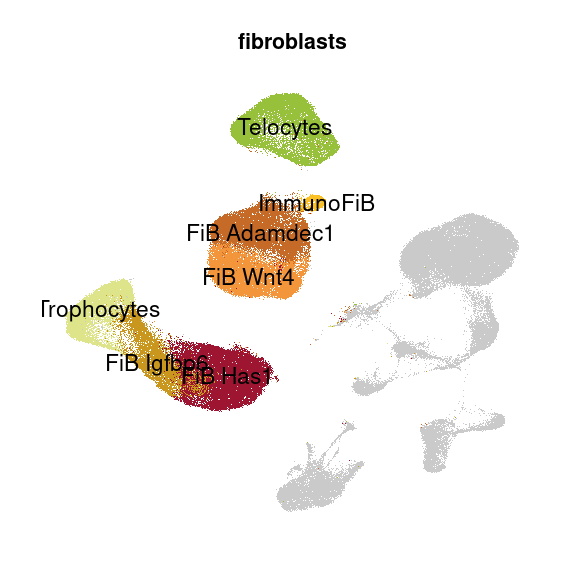

```r
plot_grid(plotlist = lapply(c("fibroblasts"),
       function(x){
         dp = DimPlot(alldata, group.by = x, label = TRUE, shuffle = TRUE) +
            scale_color_manual(values = color_list, na.value = "#CACACA") +
            dimtheme & NoLegend() & NoAxes()
         dp$layers[[2]]$aes_params$size = 3
         dp
       }), ncol = 1)
```

```r
alldata@active.assay <- "RNA"
alldata[["CCA"]] = NULL

alldata <- FindVariableFeatures(alldata)
alldata <- ScaleData(alldata, features = VariableFeatures(alldata))

fibroblasts =
  subset(alldata,
         cells = WhichCells(
           alldata, expression =
             fibroblasts %in% alldata$NamedCluster))

rm(alldata)
trash = gc()

saveRDS(fibroblasts,paste0(datadir,"fibroblasts.rds"))
```